# Stos_D_FinalTermProject_s

## Dylan Stos

"On my honor, as a student, I have neither giver nor received unuthorized aid on this academic work."

FAKEID the ticket buyer's unique ID number YXdefect "X" indicates the year Y3defect=1 for year 2 ticket holders that did not renew for year 3 Y3defect=0 for year 2 ticket holders that did renew for year 3 Y2defect=1 for year 1 ticket holders that did not renew for year 2 Y2defect=0 for year 1 ticket holders that did renew for year 2 YXGZ "X" indicates the year, "Z" indicates the game e.g. Y2G4=1 for the tickets being used for game 4 in year 2 e.g. Y2G4=0 for the tickets not being used for game 4 in year 2 YXprice "X" indicates the year the price paid per ticket in the indicated year YEARS the number of years as a season ticket holder BACKER 1=member of the team's "backer" club 0=not a member of the team's "backer" club AGE age of the ticket buyer (blank=unknown) INCOME income category of the ticket buyer (0=low, 6=high) CHILD 1=at least one child age 0-18 in household (blank indicates none or unknown) GNDR 1=male, 0=female, blank=unknown OWNHOME 1=owns home, 0=does not own home, blank=unknown SPORT purchased appended data 1=subscribes to a sports magazine, 0=does not subscribe to a sports magazine, blank = unknown COMP purchased appended data 1=owns a PC (blank indicates does not own a PC or unknown) PCTMARR appended census data at zip code level percentage of married heads of household HOMEVAL appended census data at zip code level average value of homes in 1000s of dollars

```python
import numpy as np
import pandas as pd
import matplotlib.pyplot as plt
import seaborn as sns
%matplotlib inline

#import decisiontreeclassifier
from sklearn import tree
from sklearn.tree import DecisionTreeClassifier
#import logisticregression classifier
from sklearn.linear_model import LogisticRegression
import statsmodels.api as sm
#import knn classifier
from sklearn.neighbors import KNeighborsClassifier

from sklearn import svm
from sklearn.neural_network import MLPClassifier


#ensemble classifier
from sklearn.ensemble import RandomForestClassifier
from sklearn.ensemble import GradientBoostingClassifier  #GBM algorithm

from sklearn.metrics import classification_report, f1_score, accuracy_score, confusion_matrix
from sklearn.model_selection import StratifiedKFold, cross_val_score, train_test_split, GridSearchCV, RandomizedSearchCV
from sklearn import metrics
from sklearn.metrics import roc_auc_score, auc

# feature selection
from sklearn.feature_selection import RFE
from sklearn.ensemble import ExtraTreesClassifier
from sklearn.feature_selection import SelectKBest
from sklearn.feature_selection import chi2

import scipy.stats as stats
```

```python
#Downloading data

df=pd.read_excel("train_test_dataset.xlsx")
df.head()
```

|  | FAKEID | Y2defect | Y1G5 | Y1G4 | Y1G3 | Y1G2 | Y1G1 | Y1price | YEARS | BACKER | AGE | INCOME | CHILD | GNDR | OWNHOME | SPORT | COMP | PCTMARR | HOMEVAL |
| --- | --- | --- | --- | --- | --- | --- | --- | --- | --- | --- | --- | --- | --- | --- | --- | --- | --- | --- | --- |
| 0 | 580V74KT | 0 | 0 | 0 | 1 | 1 | 1 | 15 | 8 | 1 | 94 | 4 | NaN | 0 | 1 | NaN |  | 77 | 203 |
| 1 | 298S54OK | 1 | 0 | 0 | 1 | 0 | 1 | 15 | 3 | 1 |  |  | NaN | 0 | 0 | NaN | 1 | 53 | 68 |
| 2 | 268D25AO | 1 | 1 | 0 | 0 | 0 | 1 | 15 | 11 | 1 | 67 | 2 | NaN | 0 | 1 | 0.0 |  | 50 | 38 |
| 3 | 312Q12WV | 1 | 1 | 0 | 1 | 0 | 1 | 15 | 4 | 0 | 62 | 4 |  | 1 | 1 | 0.0 | 1 | 60 | 68 |
| 4 | 420R23VB | 0 | 0 | 0 | 1 | 0 | 0 | 15 | 5 | 0 | 89 | 4 |  | 1 | 1 | 0.0 |  | 65 | 194 |

```python
#Info on all the variables in the data set

df.info()
```

```
<class 'pandas.core.frame.DataFrame'>
RangeIndex: 9216 entries, 0 to 9215
Data columns (total 19 columns):
FAKEID      9216 non-null object
Y2defect    9216 non-null int64
Y1G5        9216 non-null int64
Y1G4        9216 non-null int64
Y1G3        9216 non-null int64
Y1G2        9216 non-null int64
Y1G1        9216 non-null int64
Y1price     9216 non-null int64
YEARS       9216 non-null int64
BACKER      9216 non-null int64
AGE         9216 non-null object
INCOME      9216 non-null object
CHILD       4549 non-null object
GNDR        9216 non-null object
OWNHOME     9216 non-null object
SPORT       4273 non-null float64
COMP        9216 non-null object
PCTMARR     9216 non-null int64
HOMEVAL     9216 non-null int64
dtypes: float64(1), int64(11), object(7)
memory usage: 1.3+ MB
```

```python
#How many values are null in each variable

df.isnull().sum()
```

```
FAKEID         0
Y2defect       0
Y1G5           0
Y1G4           0
Y1G3           0
Y1G2           0
Y1G1           0
Y1price        0
YEARS          0
BACKER         0
AGE            0
INCOME         0
CHILD       4667
GNDR           0
OWNHOME        0
SPORT       4943
COMP           0
PCTMARR        0
HOMEVAL        0
dtype: int64
```

# Data Cleaning & Transformation

```python
#Replaceing blank data with NaN

df = df.replace(r'\s+', np.nan, regex=True)
df.head()
```

|  | FAKEID | Y2defect | Y1G5 | Y1G4 | Y1G3 | Y1G2 | Y1G1 | Y1price | YEARS | BACKER | AGE | INCOME | CHILD | GNDR | OWNHOME | SPORT | COMP | PCTMARR | HOMEVAL |
| --- | --- | --- | --- | --- | --- | --- | --- | --- | --- | --- | --- | --- | --- | --- | --- | --- | --- | --- | --- |
| 0 | 580V74KT | 0 | 0 | 0 | 1 | 1 | 1 | 15 | 8 | 1 | 94.0 | 4.0 | NaN | 0.0 | 1.0 | NaN | NaN | 77 | 203 |
| 1 | 298S54OK | 1 | 0 | 0 | 1 | 0 | 1 | 15 | 3 | 1 | NaN | NaN | NaN | 0.0 | 0.0 | NaN | 1.0 | 53 | 68 |
| 2 | 268D25AO | 1 | 1 | 0 | 0 | 0 | 1 | 15 | 11 | 1 | 67.0 | 2.0 | NaN | 0.0 | 1.0 | 0.0 | NaN | 50 | 38 |
| 3 | 312Q12WV | 1 | 1 | 0 | 1 | 0 | 1 | 15 | 4 | 0 | 62.0 | 4.0 | NaN | 1.0 | 1.0 | 0.0 | 1.0 | 60 | 68 |
| 4 | 420R23VB | 0 | 0 | 0 | 1 | 0 | 0 | 15 | 5 | 0 | 89.0 | 4.0 | NaN | 1.0 | 1.0 | 0.0 | NaN | 65 | 194 |

```python
#How many values are null in each variable

df.isnull().sum()
```

```
FAKEID         0
Y2defect       0
Y1G5           0
Y1G4           0
Y1G3           0
Y1G2           0
Y1G1           0
Y1price        0
YEARS          0
BACKER         0
AGE         1993
INCOME      1944
CHILD       8634
GNDR         498
OWNHOME     1999
SPORT       4943
COMP        8207
PCTMARR        0
HOMEVAL        0
dtype: int64
```

```python
#Dropping variables with the most null values and that wouldn't affect our analysis

df = df.drop(['CHILD', 'SPORT', 'COMP'], axis=1)
df.head()
```

|  | FAKEID | Y2defect | Y1G5 | Y1G4 | Y1G3 | Y1G2 | Y1G1 | Y1price | YEARS | BACKER | AGE | INCOME | GNDR | OWNHOME | PCTMARR | HOMEVAL |
| --- | --- | --- | --- | --- | --- | --- | --- | --- | --- | --- | --- | --- | --- | --- | --- | --- |
| 0 | 580V74KT | 0 | 0 | 0 | 1 | 1 | 1 | 15 | 8 | 1 | 94.0 | 4.0 | 0.0 | 1.0 | 77 | 203 |
| 1 | 298S54OK | 1 | 0 | 0 | 1 | 0 | 1 | 15 | 3 | 1 | NaN | NaN | 0.0 | 0.0 | 53 | 68 |
| 2 | 268D25AO | 1 | 1 | 0 | 0 | 0 | 1 | 15 | 11 | 1 | 67.0 | 2.0 | 0.0 | 1.0 | 50 | 38 |
| 3 | 312Q12WV | 1 | 1 | 0 | 1 | 0 | 1 | 15 | 4 | 0 | 62.0 | 4.0 | 1.0 | 1.0 | 60 | 68 |
| 4 | 420R23VB | 0 | 0 | 0 | 1 | 0 | 0 | 15 | 5 | 0 | 89.0 | 4.0 | 1.0 | 1.0 | 65 | 194 |

```python
#How values are null in each variable

df.isnull().sum()
```

```
FAKEID         0
Y2defect       0
Y1G5           0
Y1G4           0
Y1G3           0
Y1G2           0
Y1G1           0
Y1price        0
YEARS          0
BACKER         0
AGE         1993
INCOME      1944
GNDR         498
OWNHOME     1999
PCTMARR        0
HOMEVAL        0
dtype: int64
```

```python
#Creating a Y1GmAttnd by adding each individual game attendance

df['Y1GmAttnd'] = df['Y1G5'] + df['Y1G4'] + df['Y1G3'] + df['Y1G2'] + df['Y1G1']
df.head()
```

|  | FAKEID | Y2defect | Y1G5 | Y1G4 | Y1G3 | Y1G2 | Y1G1 | Y1price | YEARS | BACKER | AGE | INCOME | GNDR | OWNHOME | PCTMARR | HOMEVAL | Y1GmAttnd |
| --- | --- | --- | --- | --- | --- | --- | --- | --- | --- | --- | --- | --- | --- | --- | --- | --- | --- |
| 0 | 580V74KT | 0 | 0 | 0 | 1 | 1 | 1 | 15 | 8 | 1 | 94.0 | 4.0 | 0.0 | 1.0 | 77 | 203 | 3 |
| 1 | 298S54OK | 1 | 0 | 0 | 1 | 0 | 1 | 15 | 3 | 1 | NaN | NaN | 0.0 | 0.0 | 53 | 68 | 2 |
| 2 | 268D25AO | 1 | 1 | 0 | 0 | 0 | 1 | 15 | 11 | 1 | 67.0 | 2.0 | 0.0 | 1.0 | 50 | 38 | 2 |
| 3 | 312Q12WV | 1 | 1 | 0 | 1 | 0 | 1 | 15 | 4 | 0 | 62.0 | 4.0 | 1.0 | 1.0 | 60 | 68 | 3 |
| 4 | 420R23VB | 0 | 0 | 0 | 1 | 0 | 0 | 15 | 5 | 0 | 89.0 | 4.0 | 1.0 | 1.0 | 65 | 194 | 1 |

```python
#Dropping the year 1 game attendance

df = df.drop(['Y1G5', 'Y1G4', 'Y1G3', 'Y1G2', 'Y1G1'], axis=1)
df.head()
```

|  | FAKEID | Y2defect | Y1price | YEARS | BACKER | AGE | INCOME | GNDR | OWNHOME | PCTMARR | HOMEVAL | Y1GmAttnd |
| --- | --- | --- | --- | --- | --- | --- | --- | --- | --- | --- | --- | --- |
| 0 | 580V74KT | 0 | 15 | 8 | 1 | 94.0 | 4.0 | 0.0 | 1.0 | 77 | 203 | 3 |
| 1 | 298S54OK | 1 | 15 | 3 | 1 | NaN | NaN | 0.0 | 0.0 | 53 | 68 | 2 |
| 2 | 268D25AO | 1 | 15 | 11 | 1 | 67.0 | 2.0 | 0.0 | 1.0 | 50 | 38 | 2 |
| 3 | 312Q12WV | 1 | 15 | 4 | 0 | 62.0 | 4.0 | 1.0 | 1.0 | 60 | 68 | 3 |
| 4 | 420R23VB | 0 | 15 | 5 | 0 | 89.0 | 4.0 | 1.0 | 1.0 | 65 | 194 | 1 |

```python
#Median of age

df['AGE'].median()
```

```
63.0
```

```python
#Median of years

df['YEARS'].median()
```

```
6.0
```

```python
#Replacing null values with median age

df = df.replace({'AGE': {np.nan: 63}})
df.head()
```

|  | FAKEID | Y2defect | Y1price | YEARS | BACKER | AGE | INCOME | GNDR | OWNHOME | PCTMARR | HOMEVAL | Y1GmAttnd |
| --- | --- | --- | --- | --- | --- | --- | --- | --- | --- | --- | --- | --- |
| 0 | 580V74KT | 0 | 15 | 8 | 1 | 94.0 | 4.0 | 0.0 | 1.0 | 77 | 203 | 3 |
| 1 | 298S54OK | 1 | 15 | 3 | 1 | 63.0 | NaN | 0.0 | 0.0 | 53 | 68 | 2 |
| 2 | 268D25AO | 1 | 15 | 11 | 1 | 67.0 | 2.0 | 0.0 | 1.0 | 50 | 38 | 2 |
| 3 | 312Q12WV | 1 | 15 | 4 | 0 | 62.0 | 4.0 | 1.0 | 1.0 | 60 | 68 | 3 |
| 4 | 420R23VB | 0 | 15 | 5 | 0 | 89.0 | 4.0 | 1.0 | 1.0 | 65 | 194 | 1 |

```python
#Replacing null values with median years

df = df.replace({'YEARS': {np.nan: 6}})
df.head()
```

|  | FAKEID | Y2defect | Y1price | YEARS | BACKER | AGE | INCOME | GNDR | OWNHOME | PCTMARR | HOMEVAL | Y1GmAttnd |
| --- | --- | --- | --- | --- | --- | --- | --- | --- | --- | --- | --- | --- |
| 0 | 580V74KT | 0 | 15 | 8 | 1 | 94.0 | 4.0 | 0.0 | 1.0 | 77 | 203 | 3 |
| 1 | 298S54OK | 1 | 15 | 3 | 1 | 63.0 | NaN | 0.0 | 0.0 | 53 | 68 | 2 |
| 2 | 268D25AO | 1 | 15 | 11 | 1 | 67.0 | 2.0 | 0.0 | 1.0 | 50 | 38 | 2 |
| 3 | 312Q12WV | 1 | 15 | 4 | 0 | 62.0 | 4.0 | 1.0 | 1.0 | 60 | 68 | 3 |
| 4 | 420R23VB | 0 | 15 | 5 | 0 | 89.0 | 4.0 | 1.0 | 1.0 | 65 | 194 | 1 |

```python
#Seeing the information of the data set

df.info()
```

```
<class 'pandas.core.frame.DataFrame'>
RangeIndex: 9216 entries, 0 to 9215
Data columns (total 12 columns):
FAKEID       9216 non-null object
Y2defect     9216 non-null int64
Y1price      9216 non-null int64
YEARS        9216 non-null int64
BACKER       9216 non-null int64
AGE          9216 non-null float64
INCOME       7272 non-null float64
GNDR         8718 non-null float64
OWNHOME      7217 non-null float64
PCTMARR      9216 non-null int64
HOMEVAL      9216 non-null int64
Y1GmAttnd    9216 non-null int64
dtypes: float64(4), int64(7), object(1)
memory usage: 864.1+ KB
```

```python
#How many null values are there in each variable

df.isnull().sum()
```

```
FAKEID          0
Y2defect        0
Y1price         0
YEARS           0
BACKER          0
AGE             0
INCOME       1944
GNDR          498
OWNHOME      1999
PCTMARR         0
HOMEVAL         0
Y1GmAttnd       0
dtype: int64
```

```python
#Dropping all null values

df = df.dropna()
df.info()
```

```
<class 'pandas.core.frame.DataFrame'>
Int64Index: 5145 entries, 0 to 9214
Data columns (total 12 columns):
FAKEID       5145 non-null object
Y2defect     5145 non-null int64
Y1price      5145 non-null int64
YEARS        5145 non-null int64
BACKER       5145 non-null int64
AGE          5145 non-null float64
INCOME       5145 non-null float64
GNDR         5145 non-null float64
OWNHOME      5145 non-null float64
PCTMARR      5145 non-null int64
HOMEVAL      5145 non-null int64
Y1GmAttnd    5145 non-null int64
dtypes: float64(4), int64(7), object(1)
memory usage: 522.5+ KB
```

# Model Development

### Decision Tree Classifier

```python
y = df['Y2defect']
X = df[['BACKER', 'Y1GmAttnd']]
```

```python
X_train, X_test, y_train, y_test = train_test_split(X, y, test_size=0.3, random_state=0)
```

```python
dt = DecisionTreeClassifier()
dt.fit(X_train, y_train)
```

```
DecisionTreeClassifier(class_weight=None, criterion='gini', max_depth=None,
            max_features=None, max_leaf_nodes=None,
            min_impurity_decrease=0.0, min_impurity_split=None,
            min_samples_leaf=1, min_samples_split=2,
            min_weight_fraction_leaf=0.0, presort=False, random_state=None,
            splitter='best')
```

```python
print metrics.accuracy_score(y_test, dt.predict(X_test))
print metrics.confusion_matrix(y_test, dt.predict(X_test))
print metrics.classification_report(y_test, dt.predict(X_test))
print metrics.roc_auc_score(y_test, dt.predict(X_test))
```

```
0.593264248705
[[550 223]
 [405 366]]
             precision    recall  f1-score   support

          0       0.58      0.71      0.64       773
          1       0.62      0.47      0.54       771

avg / total       0.60      0.59      0.59      1544

0.593110877324
```

The Decsion Tree model came out to be 59.3% accurate

### Random Forest Classifier

```python
clf = RandomForestClassifier(n_estimators=20)
clf=clf.fit(X, y)
clf.score(X,y)
```

```
0.59378036929057332
```

```python
print metrics.accuracy_score(y, clf.predict(X))
print metrics.confusion_matrix(y, clf.predict(X))
print metrics.classification_report(y, clf.predict(X))
```

```
0.593780369291
[[1610  999]
 [1091 1445]]
             precision    recall  f1-score   support

          0       0.60      0.62      0.61      2609
          1       0.59      0.57      0.58      2536

avg / total       0.59      0.59      0.59      5145
```

The Random Forest Classifier model came out to be 59.4% accurate

### KNN Classifier

```python
X_train, X_test, y_train, y_test = train_test_split(X, y, test_size=0.3, random_state=0)
knn = KNeighborsClassifier()
knn.fit(X_train, y_train)
```

```
KNeighborsClassifier(algorithm='auto', leaf_size=30, metric='minkowski',
           metric_params=None, n_jobs=1, n_neighbors=5, p=2,
           weights='uniform')
```

```python
print metrics.accuracy_score(y_test, knn.predict(X_test))
print metrics.confusion_matrix(y_test, knn.predict(X_test))
print metrics.classification_report(y_test, knn.predict(X_test))
print metrics.roc_auc_score(y_test, knn.predict(X_test))
```

```
0.545984455959
[[336 437]
 [264 507]]
             precision    recall  f1-score   support

          0       0.56      0.43      0.49       773
          1       0.54      0.66      0.59       771

avg / total       0.55      0.55      0.54      1544

0.546128832534
```

The KNN Classifier model came out to be 54.6% accurate

# Model Deployment & Prepare Entry Data

```python
#Downloading data set

df2 = pd.read_excel("validation_dataset.xlsx")
df2.head()
```

|  | FAKEID | Y3defect | Y2G5 | Y2G4 | Y2G3 | Y2G2 | Y2G1 | Y2price | YEARS | BACKER | AGE | INCOME | CHILD | GNDR | OWNHOME | SPORT | COMP | PCTMARR | HOMEVAL |
| --- | --- | --- | --- | --- | --- | --- | --- | --- | --- | --- | --- | --- | --- | --- | --- | --- | --- | --- | --- |
| 0 | 580D24RR | NaN | 0 | 0 | 1 | 1 | 0 | 15 | 5 | 0 | 49.0 | 4 | NaN | 0 | 1 | 0.0 |  | 66 | 64 |
| 1 | 179Q96NO | NaN | 1 | 1 | 1 | 1 | 1 | 25 | 9 | 1 | 84.0 | 5 |  | 0 |  | 0.0 |  | 67 | 128 |
| 2 | 050Z45TB | NaN | 1 | 0 | 1 | 1 | 0 | 15 | 5 | 1 | NaN |  | NaN | 0 | 0 | NaN | 1 | 52 | 113 |
| 3 | 399V18KY | NaN | 0 | 0 | 1 | 1 | 0 | 15 | 1 | 0 | 34.0 | 4 | 1 | 0 | 1 | NaN |  | 65 | 81 |
| 4 | 009A52KP | NaN | 0 | 1 | 0 | 1 | 0 | 25 | 9 | 1 | 59.0 | 4 | NaN | 1 | 1 | 0.0 |  | 65 | 110 |

```python
#Creating a Y2GmAttnd by adding each individual game attendance

df2['Y2GmAttnd'] = df2['Y2G5'] + df2['Y2G4'] + df2['Y2G3'] + df2['Y2G2'] + df2['Y2G1']
df2.head()
```

|  | FAKEID | Y3defect | Y2G5 | Y2G4 | Y2G3 | Y2G2 | Y2G1 | Y2price | YEARS | BACKER | AGE | INCOME | CHILD | GNDR | OWNHOME | SPORT | COMP | PCTMARR | HOMEVAL | Y2GmAttnd |
| --- | --- | --- | --- | --- | --- | --- | --- | --- | --- | --- | --- | --- | --- | --- | --- | --- | --- | --- | --- | --- |
| 0 | 580D24RR | NaN | 0 | 0 | 1 | 1 | 0 | 15 | 5 | 0 | 49.0 | 4 | NaN | 0 | 1 | 0.0 |  | 66 | 64 | 2 |
| 1 | 179Q96NO | NaN | 1 | 1 | 1 | 1 | 1 | 25 | 9 | 1 | 84.0 | 5 |  | 0 |  | 0.0 |  | 67 | 128 | 5 |
| 2 | 050Z45TB | NaN | 1 | 0 | 1 | 1 | 0 | 15 | 5 | 1 | NaN |  | NaN | 0 | 0 | NaN | 1 | 52 | 113 | 3 |
| 3 | 399V18KY | NaN | 0 | 0 | 1 | 1 | 0 | 15 | 1 | 0 | 34.0 | 4 | 1 | 0 | 1 | NaN |  | 65 | 81 | 2 |
| 4 | 009A52KP | NaN | 0 | 1 | 0 | 1 | 0 | 25 | 9 | 1 | 59.0 | 4 | NaN | 1 | 1 | 0.0 |  | 65 | 110 | 2 |

```python
#Dropping the year 1 game attendance

df2 = df2.drop(['Y2G5', 'Y2G4', 'Y2G3', 'Y2G2', 'Y2G1'], axis=1)
df2.head()
```

|  | FAKEID | Y3defect | Y2price | YEARS | BACKER | AGE | INCOME | CHILD | GNDR | OWNHOME | SPORT | COMP | PCTMARR | HOMEVAL | Y2GmAttnd |
| --- | --- | --- | --- | --- | --- | --- | --- | --- | --- | --- | --- | --- | --- | --- | --- |
| 0 | 580D24RR | NaN | 15 | 5 | 0 | 49.0 | 4 | NaN | 0 | 1 | 0.0 |  | 66 | 64 | 2 |
| 1 | 179Q96NO | NaN | 25 | 9 | 1 | 84.0 | 5 |  | 0 |  | 0.0 |  | 67 | 128 | 5 |
| 2 | 050Z45TB | NaN | 15 | 5 | 1 | NaN |  | NaN | 0 | 0 | NaN | 1 | 52 | 113 | 3 |
| 3 | 399V18KY | NaN | 15 | 1 | 0 | 34.0 | 4 | 1 | 0 | 1 | NaN |  | 65 | 81 | 2 |
| 4 | 009A52KP | NaN | 25 | 9 | 1 | 59.0 | 4 | NaN | 1 | 1 | 0.0 |  | 65 | 110 | 2 |

```python
#Replacing all blank values with NaN

df2 = df2.replace(r'\s+', np.nan, regex=True)
df2.head()
```

|  | FAKEID | Y3defect | Y2price | YEARS | BACKER | AGE | INCOME | CHILD | GNDR | OWNHOME | SPORT | COMP | PCTMARR | HOMEVAL | Y2GmAttnd |
| --- | --- | --- | --- | --- | --- | --- | --- | --- | --- | --- | --- | --- | --- | --- | --- |
| 0 | 580D24RR | NaN | 15 | 5 | 0 | 49.0 | 4.0 | NaN | 0.0 | 1.0 | 0.0 | NaN | 66 | 64 | 2 |
| 1 | 179Q96NO | NaN | 25 | 9 | 1 | 84.0 | 5.0 | NaN | 0.0 | NaN | 0.0 | NaN | 67 | 128 | 5 |
| 2 | 050Z45TB | NaN | 15 | 5 | 1 | NaN | NaN | NaN | 0.0 | 0.0 | NaN | 1.0 | 52 | 113 | 3 |
| 3 | 399V18KY | NaN | 15 | 1 | 0 | 34.0 | 4.0 | 1.0 | 0.0 | 1.0 | NaN | NaN | 65 | 81 | 2 |
| 4 | 009A52KP | NaN | 25 | 9 | 1 | 59.0 | 4.0 | NaN | 1.0 | 1.0 | 0.0 | NaN | 65 | 110 | 2 |

```python
#How many values are null in each variable

df2.isnull().sum()
```

```
FAKEID          0
Y3defect     9542
Y2price         0
YEARS           0
BACKER          0
AGE          2487
INCOME       2415
CHILD        8941
GNDR          565
OWNHOME      1952
SPORT        5362
COMP         8586
PCTMARR         0
HOMEVAL         0
Y2GmAttnd       0
dtype: int64
```

```python
#Dropping variables that have the most null values and wouldn't affect our analysis

df2 = df2.drop(['CHILD', 'COMP', 'SPORT'], axis=1)
df2.head()
```

|  | FAKEID | Y3defect | Y2price | YEARS | BACKER | AGE | INCOME | GNDR | OWNHOME | PCTMARR | HOMEVAL | Y2GmAttnd |
| --- | --- | --- | --- | --- | --- | --- | --- | --- | --- | --- | --- | --- |
| 0 | 580D24RR | NaN | 15 | 5 | 0 | 49.0 | 4.0 | 0.0 | 1.0 | 66 | 64 | 2 |
| 1 | 179Q96NO | NaN | 25 | 9 | 1 | 84.0 | 5.0 | 0.0 | NaN | 67 | 128 | 5 |
| 2 | 050Z45TB | NaN | 15 | 5 | 1 | NaN | NaN | 0.0 | 0.0 | 52 | 113 | 3 |
| 3 | 399V18KY | NaN | 15 | 1 | 0 | 34.0 | 4.0 | 0.0 | 1.0 | 65 | 81 | 2 |
| 4 | 009A52KP | NaN | 25 | 9 | 1 | 59.0 | 4.0 | 1.0 | 1.0 | 65 | 110 | 2 |

```python
#Information of each variable

df2.info()
```

```
<class 'pandas.core.frame.DataFrame'>
RangeIndex: 9542 entries, 0 to 9541
Data columns (total 12 columns):
FAKEID       9542 non-null object
Y3defect     0 non-null float64
Y2price      9542 non-null int64
YEARS        9542 non-null int64
BACKER       9542 non-null int64
AGE          7055 non-null float64
INCOME       7127 non-null float64
GNDR         8977 non-null float64
OWNHOME      7590 non-null float64
PCTMARR      9542 non-null int64
HOMEVAL      9542 non-null int64
Y2GmAttnd    9542 non-null int64
dtypes: float64(5), int64(6), object(1)
memory usage: 894.6+ KB
```

```python
#How many values are null in each variable

df2.isnull().sum()
```

```
FAKEID          0
Y3defect     9542
Y2price         0
YEARS           0
BACKER          0
AGE          2487
INCOME       2415
GNDR          565
OWNHOME      1952
PCTMARR         0
HOMEVAL         0
Y2GmAttnd       0
dtype: int64
```

```python
#Median of age

df2['AGE'].median()
```

```
63.0
```

```python
#Replacing null values with the median age

df2 = df2.replace({'AGE': {np.nan: 63}})
df2.head()
```

|  | FAKEID | Y3defect | Y2price | YEARS | BACKER | AGE | INCOME | GNDR | OWNHOME | PCTMARR | HOMEVAL | Y2GmAttnd |
| --- | --- | --- | --- | --- | --- | --- | --- | --- | --- | --- | --- | --- |
| 0 | 580D24RR | NaN | 15 | 5 | 0 | 49.0 | 4.0 | 0.0 | 1.0 | 66 | 64 | 2 |
| 1 | 179Q96NO | NaN | 25 | 9 | 1 | 84.0 | 5.0 | 0.0 | NaN | 67 | 128 | 5 |
| 2 | 050Z45TB | NaN | 15 | 5 | 1 | 63.0 | NaN | 0.0 | 0.0 | 52 | 113 | 3 |
| 3 | 399V18KY | NaN | 15 | 1 | 0 | 34.0 | 4.0 | 0.0 | 1.0 | 65 | 81 | 2 |
| 4 | 009A52KP | NaN | 25 | 9 | 1 | 59.0 | 4.0 | 1.0 | 1.0 | 65 | 110 | 2 |

```python
#Information on each variable

df2.info()
```

```
<class 'pandas.core.frame.DataFrame'>
RangeIndex: 9542 entries, 0 to 9541
Data columns (total 12 columns):
FAKEID       9542 non-null object
Y3defect     0 non-null float64
Y2price      9542 non-null int64
YEARS        9542 non-null int64
BACKER       9542 non-null int64
AGE          9542 non-null float64
INCOME       7127 non-null float64
GNDR         8977 non-null float64
OWNHOME      7590 non-null float64
PCTMARR      9542 non-null int64
HOMEVAL      9542 non-null int64
Y2GmAttnd    9542 non-null int64
dtypes: float64(5), int64(6), object(1)
memory usage: 894.6+ KB
```

```python
#How many null values are in each variable

df2.isnull().sum()
```

```
FAKEID          0
Y3defect     9542
Y2price         0
YEARS           0
BACKER          0
AGE             0
INCOME       2415
GNDR          565
OWNHOME      1952
PCTMARR         0
HOMEVAL         0
Y2GmAttnd       0
dtype: int64
```

```python
#Dropping variables with the most null values and that wouldn't affect our analysis

df2 = df2.drop(['OWNHOME', 'GNDR', 'INCOME'], axis=1)
df2.head()
```

|  | FAKEID | Y3defect | Y2price | YEARS | BACKER | AGE | PCTMARR | HOMEVAL | Y2GmAttnd |
| --- | --- | --- | --- | --- | --- | --- | --- | --- | --- |
| 0 | 580D24RR | NaN | 15 | 5 | 0 | 49.0 | 66 | 64 | 2 |
| 1 | 179Q96NO | NaN | 25 | 9 | 1 | 84.0 | 67 | 128 | 5 |
| 2 | 050Z45TB | NaN | 15 | 5 | 1 | 63.0 | 52 | 113 | 3 |
| 3 | 399V18KY | NaN | 15 | 1 | 0 | 34.0 | 65 | 81 | 2 |
| 4 | 009A52KP | NaN | 25 | 9 | 1 | 59.0 | 65 | 110 | 2 |

```python
#How many null values are in each variable

df2.isnull().sum()
```

```
FAKEID          0
Y3defect     9542
Y2price         0
YEARS           0
BACKER          0
AGE             0
PCTMARR         0
HOMEVAL         0
Y2GmAttnd       0
dtype: int64
```

```python
#Validating

validation = df2[['BACKER', 'Y2GmAttnd']]
validation.info()
```

```
<class 'pandas.core.frame.DataFrame'>
RangeIndex: 9542 entries, 0 to 9541
Data columns (total 2 columns):
BACKER       9542 non-null int64
Y2GmAttnd    9542 non-null int64
dtypes: int64(2)
memory usage: 149.2 KB
```

```python
fakeid = pd.DataFrame(df2['FAKEID'])
fakeid.head()
```

|  | FAKEID |
| --- | --- |
| 0 | 580D24RR |
| 1 | 179Q96NO |
| 2 | 050Z45TB |
| 3 | 399V18KY |
| 4 | 009A52KP |

```python
# applying the decision tree model to validation dataset
output_scoring = dt.predict(validation)

# generating probability for defect for each fan
probs = dt.predict_proba(validation)
probs = pd.DataFrame(probs, columns=['prob of Renewal', 'prob of Defect'])

# joining two dataframes (fakeid and probability)
risky_fans = fakeid.join(probs)

# joining dataframes (fakeid, probability, and prediction)
predicted_y= pd.DataFrame(output_scoring, columns=['Predicted Defect'])
risky_fans = risky_fans.join(predicted_y)

# generating submission file
risky_fans.to_csv("submissionentry.csv", index=False)
```

# Data Visualization

```
array([[<matplotlib.axes._subplots.AxesSubplot object at 0x11753c7d0>,
        <matplotlib.axes._subplots.AxesSubplot object at 0x1c221e2490>]], dtype=object)
```

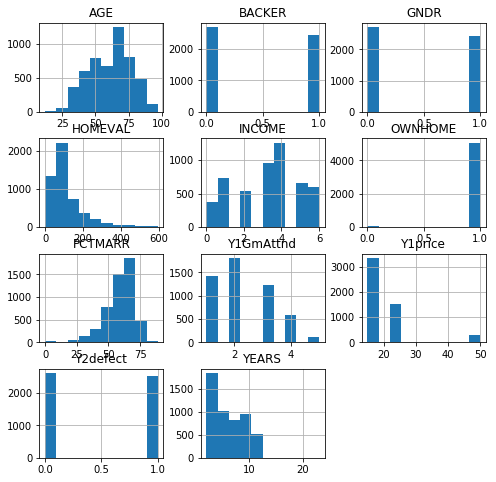

```python
#histograms to show how each individual variable compares its demographic (i.e age, gender, etc.)

df.hist(figsize=(8, 8))
```

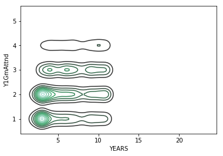

```python
#Relationship between YEARS and Y1GmAttnd

sns.kdeplot(df.YEARS, df.Y1GmAttnd)
```

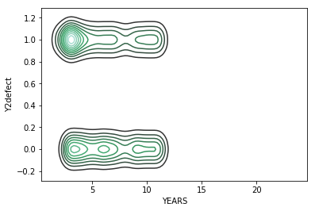

```python
#Relationship between YEARS and Y2defect

sns.kdeplot(df.YEARS, df.Y2defect)
```

With the above graph we can conlude that people who have been a season ticket holder for less than five years are more likely to defect than those who have been a season ticket holder for more than five years.

# Exploratory Data Analysis

```python
#Information on each variable

df.info()
```

```
<class 'pandas.core.frame.DataFrame'>
Int64Index: 5145 entries, 0 to 9214
Data columns (total 12 columns):
FAKEID       5145 non-null object
Y2defect     5145 non-null int64
Y1price      5145 non-null int64
YEARS        5145 non-null int64
BACKER       5145 non-null int64
AGE          5145 non-null float64
INCOME       5145 non-null float64
GNDR         5145 non-null float64
OWNHOME      5145 non-null float64
PCTMARR      5145 non-null int64
HOMEVAL      5145 non-null int64
Y1GmAttnd    5145 non-null int64
dtypes: float64(4), int64(7), object(1)
memory usage: 682.5+ KB
```

FAKEID is not numerical

```python
#FAKEID is not numerical, making it hard to use any classifiers

df = df.drop(['FAKEID'], axis=1)
df.head()
```

|  | Y2defect | Y1price | YEARS | BACKER | AGE | INCOME | GNDR | OWNHOME | PCTMARR | HOMEVAL | Y1GmAttnd |
| --- | --- | --- | --- | --- | --- | --- | --- | --- | --- | --- | --- |
| 0 | 0 | 15 | 8 | 1 | 94.0 | 4.0 | 0.0 | 1.0 | 77 | 203 | 3 |
| 2 | 1 | 15 | 11 | 1 | 67.0 | 2.0 | 0.0 | 1.0 | 50 | 38 | 2 |
| 3 | 1 | 15 | 4 | 0 | 62.0 | 4.0 | 1.0 | 1.0 | 60 | 68 | 3 |
| 4 | 0 | 15 | 5 | 0 | 89.0 | 4.0 | 1.0 | 1.0 | 65 | 194 | 1 |
| 7 | 0 | 15 | 6 | 1 | 76.0 | 5.0 | 1.0 | 1.0 | 50 | 483 | 3 |

```python
#Find out some descriptive statistics

df.describe()
```

|  | Y2defect | Y1price | YEARS | BACKER | AGE | INCOME | GNDR | OWNHOME | PCTMARR | HOMEVAL | Y1GmAttnd |
| --- | --- | --- | --- | --- | --- | --- | --- | --- | --- | --- | --- |
| count | 5145.000000 | 5145.000000 | 5145.000000 | 5145.000000 | 5145.000000 | 5145.000000 | 5145.000000 | 5145.000000 | 5145.000000 | 5145.000000 | 5145.000000 |
| mean | 0.492906 | 19.934888 | 6.322255 | 0.474636 | 60.566569 | 3.245287 | 0.472692 | 0.983479 | 59.284354 | 115.624490 | 2.255005 |
| std | 0.499998 | 8.660851 | 2.861150 | 0.499405 | 15.480670 | 1.758696 | 0.499302 | 0.127480 | 11.661462 | 91.427497 | 1.046492 |
| min | 0.000000 | 15.000000 | 2.000000 | 0.000000 | 12.000000 | 0.000000 | 0.000000 | 0.000000 | 0.000000 | 0.000000 | 1.000000 |
| 25% | 0.000000 | 15.000000 | 4.000000 | 0.000000 | 49.000000 | 2.000000 | 0.000000 | 1.000000 | 54.000000 | 58.000000 | 1.000000 |
| 50% | 0.000000 | 15.000000 | 6.000000 | 0.000000 | 63.000000 | 3.000000 | 0.000000 | 1.000000 | 61.000000 | 84.000000 | 2.000000 |
| 75% | 1.000000 | 25.000000 | 9.000000 | 1.000000 | 73.000000 | 4.000000 | 1.000000 | 1.000000 | 67.000000 | 138.000000 | 3.000000 |
| max | 1.000000 | 50.000000 | 23.000000 | 1.000000 | 97.000000 | 6.000000 | 1.000000 | 1.000000 | 89.000000 | 595.000000 | 5.000000 |

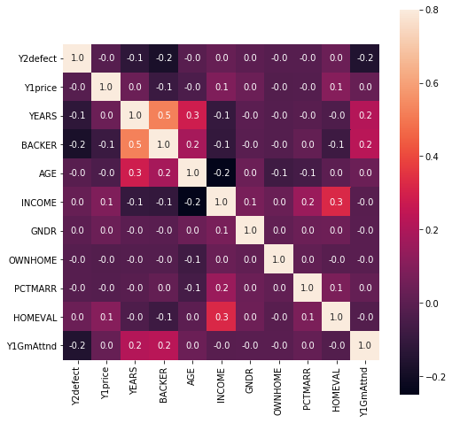

```python
#Correlation statistics in plot form

plt.figure(figsize=(8,8))
sns.heatmap(df.corr(), vmax=.8, square=True, annot=True, fmt=".1f")
```

```python
#Variance of each variable

df.var()
```

```
Y2defect        0.249998
Y1price        75.010340
YEARS           8.186178
BACKER          0.249405
AGE           239.651137
INCOME          3.093011
GNDR            0.249303
OWNHOME         0.016251
PCTMARR       135.989695
HOMEVAL      8358.987269
Y1GmAttnd       1.095147
dtype: float64
```

### Normality Testing

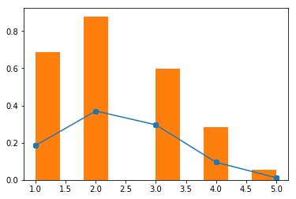

```python
#An illustration of normal distribution with Y1GmAttnd

h = sorted(df['Y1GmAttnd'])
fit = stats.norm.pdf(h, np.mean(h),np.std(h))
plt.plot(h,fit,'-o')
plt.hist(h,normed=True)
```

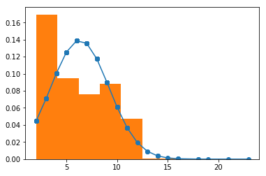

```python
#An illustration of normal distribution with YEARS

h = sorted(df['YEARS'])
fit = stats.norm.pdf(h, np.mean(h),np.std(h))
plt.plot(h,fit,'-o')
plt.hist(h,normed=True)
```

### t-testing

```python
#Test if the data is normally distributed

print stats.normaltest(df['Y1GmAttnd'])
print stats.normaltest(df['YEARS'])
```

```
NormaltestResult(statistic=291.01057145525846, pvalue=6.4247660906219316e-64)
NormaltestResult(statistic=434.46133723288352, pvalue=4.5490354341400296e-95)
```

```python
GmsAttnd = stats.normaltest(df['Y1GmAttnd'])
Yrs = stats.normaltest(df['YEARS'])

print "The chi-square statistic is %.3f and the p-value is %.3f." % GmsAttnd
print "The chi-square statistic is %.3f and the p-value is %.3f." % Yrs
```

```
The chi-square statistic is 291.011 and the p-value is 0.000.
The chi-square statistic is 434.461 and the p-value is 0.000.
```

```python
Defected = df[df['Y2defect'] == 1]['Y1GmAttnd']
Stayed = df[df['Y2defect'] == 0]['Y1GmAttnd']
stats.ttest_ind(Defected, Stayed)
```

```
Ttest_indResult(statistic=-11.293195196583728, pvalue=3.1242222649923117e-29)
```

```python
#print three decimal points

two_sample = stats.ttest_ind(Defected, Stayed)
print "The t-statistic is %.3f and the p-value is %.3f." % two_sample
```

```
The t-statistic is -11.293 and the p-value is 0.000.
```

```python
#print three decimal points

Defected = df[df['Y2defect'] == 1]['YEARS']
Stayed = df[df['Y2defect'] == 0]['YEARS']
two_sample = stats.ttest_ind(Defected, Stayed)
print "The t-statistic is %.3f and the p-value is %.3f." % two_sample
```

```
The t-statistic is -8.590 and the p-value is 0.000.
```

# Model Buidling

### Decision Tree

```python
y = df['Y2defect']
X = df.drop(['Y2defect'], axis=1)
```

```python
X_train, X_test, y_train, y_test = train_test_split(X, y, test_size=0.3, random_state=0)
dt = DecisionTreeClassifier()
dt.fit(X_train, y_train)
```

```
DecisionTreeClassifier(class_weight=None, criterion='gini', max_depth=None,
            max_features=None, max_leaf_nodes=None,
            min_impurity_decrease=0.0, min_impurity_split=None,
            min_samples_leaf=1, min_samples_split=2,
            min_weight_fraction_leaf=0.0, presort=False, random_state=None,
            splitter='best')
```

```python
print metrics.accuracy_score(y_test, dt.predict(X_test))
print "---------------------------------------------------"
print metrics.confusion_matrix(y_test, dt.predict(X_test))
print "---------------------------------------------------"
print metrics.classification_report(y_test, dt.predict(X_test))
print "---------------------------------------------------"
print metrics.roc_auc_score(y_test, dt.predict(X_test))
```

```
0.54792746114
---------------------------------------------------
[[449 324]
 [374 397]]
---------------------------------------------------
             precision    recall  f1-score   support

          0       0.55      0.58      0.56       773
          1       0.55      0.51      0.53       771

avg / total       0.55      0.55      0.55      1544

---------------------------------------------------
0.547884755102
```

The Decision Tree model is 54.7% accurate. We expect the model to be close to 54% to 55% accurate

### KNN

```python
X_train, X_test, y_train, y_test = train_test_split(X, y, test_size=0.3, random_state=0)
knn = KNeighborsClassifier()
knn.fit(X_train, y_train)
```

```
KNeighborsClassifier(algorithm='auto', leaf_size=30, metric='minkowski',
           metric_params=None, n_jobs=1, n_neighbors=5, p=2,
           weights='uniform')
```

```python
print metrics.accuracy_score(y_test, knn.predict(X_test))
print metrics.confusion_matrix(y_test, knn.predict(X_test))
print metrics.classification_report(y_test, knn.predict(X_test))
print metrics.roc_auc_score(y_test, knn.predict(X_test))
```

```
0.492875647668
[[393 380]
 [403 368]]
             precision    recall  f1-score   support

          0       0.49      0.51      0.50       773
          1       0.49      0.48      0.48       771

avg / total       0.49      0.49      0.49      1544

0.492855500912
```

The KNN model is 49.3% accurate. We expect the model to be close to 49% to 50% accurate

### Logistic Regression

```python
X_train, X_test, y_train, y_test = train_test_split(X, y, test_size=0.3, random_state=0)
lr = LogisticRegression()
lr.fit(X_train, y_train)
```

```
LogisticRegression(C=1.0, class_weight=None, dual=False, fit_intercept=True,
          intercept_scaling=1, max_iter=100, multi_class='ovr', n_jobs=1,
          penalty='l2', random_state=None, solver='liblinear', tol=0.0001,
          verbose=0, warm_start=False)
```

```python
print metrics.accuracy_score(y_test, lr.predict(X_test))
print metrics.confusion_matrix(y_test, lr.predict(X_test))
print metrics.classification_report(y_test, lr.predict(X_test))
print metrics.roc_auc_score(y_test, lr.predict(X_test))
```

```
0.59585492228
[[476 297]
 [327 444]]
             precision    recall  f1-score   support

          0       0.59      0.62      0.60       773
          1       0.60      0.58      0.59       771

avg / total       0.60      0.60      0.60      1544

0.595829075662
```

The Logistic Regression model is 59.6% accurate. We expect the model will be close to 59% to 60% accurate

# Model Selection and Evaluation

```python
y = df['Y2defect']
X = df.drop(['Y2defect'], axis=1)
```

```python
X_new = SelectKBest(chi2, k=3).fit_transform(X, y)
print X_new
```

```
[[   8.    1.  203.]
 [  11.    1.   38.]
 [   4.    0.   68.]
 ...,
 [   3.    0.   96.]
 [   6.    0.   95.]
 [   7.    1.   37.]]
```

```python
df.head()
```

|  | Y2defect | Y1price | YEARS | BACKER | AGE | INCOME | GNDR | OWNHOME | PCTMARR | HOMEVAL | Y1GmAttnd |
| --- | --- | --- | --- | --- | --- | --- | --- | --- | --- | --- | --- |
| 0 | 0 | 15 | 8 | 1 | 94.0 | 4.0 | 0.0 | 1.0 | 77 | 203 | 3 |
| 2 | 1 | 15 | 11 | 1 | 67.0 | 2.0 | 0.0 | 1.0 | 50 | 38 | 2 |
| 3 | 1 | 15 | 4 | 0 | 62.0 | 4.0 | 1.0 | 1.0 | 60 | 68 | 3 |
| 4 | 0 | 15 | 5 | 0 | 89.0 | 4.0 | 1.0 | 1.0 | 65 | 194 | 1 |
| 7 | 0 | 15 | 6 | 1 | 76.0 | 5.0 | 1.0 | 1.0 | 50 | 483 | 3 |

YEARS, BACKER and HOMEVAL have been chosen as the three best predictors

```python
X_train, X_test, y_train, y_test = train_test_split(X_new, y, test_size=0.3, random_state=0)

dt = tree.DecisionTreeClassifier()
dt.fit(X_train, y_train)
```

```
DecisionTreeClassifier(class_weight=None, criterion='gini', max_depth=None,
            max_features=None, max_leaf_nodes=None,
            min_impurity_decrease=0.0, min_impurity_split=None,
            min_samples_leaf=1, min_samples_split=2,
            min_weight_fraction_leaf=0.0, presort=False, random_state=None,
            splitter='best')
```

```python
print metrics.accuracy_score(y_test, dt.predict(X_test))
print "--------------------------------------------------------"
print metrics.confusion_matrix(y_test, dt.predict(X_test))
print "--------------------------------------------------------"
print metrics.classification_report(y_test, dt.predict(X_test))
print "--------------------------------------------------------"
print metrics.roc_auc_score(y_test, dt.predict(X_test))
```

```
0.533031088083
--------------------------------------------------------
[[483 290]
 [431 340]]
--------------------------------------------------------
             precision    recall  f1-score   support

          0       0.53      0.62      0.57       773
          1       0.54      0.44      0.49       771

avg / total       0.53      0.53      0.53      1544

--------------------------------------------------------
0.532912012591
```

AUC score is 53.3% for Decision Tree

```python
X_new_df = pd.DataFrame(X_new)
X_new_df = X_new_df.rename(columns={0: 'YEARS', 1: 'BACKER', 2: 'HOMEVAL'})
tree.export_graphviz(dt, out_file='decisiontree.dot', feature_names=X_new_df.columns)
```

```python
X_train, X_test, y_train, y_test = train_test_split(X_new, y, test_size=0.3, random_state=0)
lr = LogisticRegression()
lr.fit(X_train, y_train)
```

```
LogisticRegression(C=1.0, class_weight=None, dual=False, fit_intercept=True,
          intercept_scaling=1, max_iter=100, multi_class='ovr', n_jobs=1,
          penalty='l2', random_state=None, solver='liblinear', tol=0.0001,
          verbose=0, warm_start=False)
```

```python
print metrics.accuracy_score(y_test, lr.predict(X_test))
print metrics.confusion_matrix(y_test, lr.predict(X_test))
print metrics.classification_report(y_test, lr.predict(X_test))
print metrics.roc_auc_score(y_test, lr.predict(X_test))
```

```
0.59067357513
[[441 332]
 [300 471]]
             precision    recall  f1-score   support

          0       0.60      0.57      0.58       773
          1       0.59      0.61      0.60       771

avg / total       0.59      0.59      0.59      1544

0.590699734724
```

AUC score is 59.1% for Logistic Regression

I would recommend that the best model would be Logistics Regression since it has a higher accuracy of 59.1%

# Final Analysis and Storytelling

While analyzing the data I found that the three important variables in finding a solution to your problem of defecting ticket holders were: YEARS; how many years has the client been a ticket holder, BACKER; was the client a catbacker member and HOMEVAL; what was value of the clients current home. I came to the conclusion that the Logistics Regression model was the best fit for your problem. I came up with an AUC score of 59.1% at the conclusion of my analysis.